# Lab 1 - 7331 Data Mining

## Dan Freeman, Ireti Fasere, Timothy McWilliams, & Peter Kouvaris

### 1 - Business Understanding (10%)

### Preparing Python for Data Exploration

```python
#imports for data-preprocessing
import pandas as pd
import numpy as np

#viz libraries
import matplotlib.pyplot as plt
import seaborn as sns
%matplotlib inline
```

```python
#import data
data_file = '../data/dataset.csv'
df = pd.read_csv(data_file)
```

### 2 - Meaning & Data Types (10%)

```python
df.head(3)
```

[output not shown]

[output not shown]

### 3 - Data Quality Review (15%)

### 4 - Sample Statistics (10%)

### 5 - Visualization (15%)

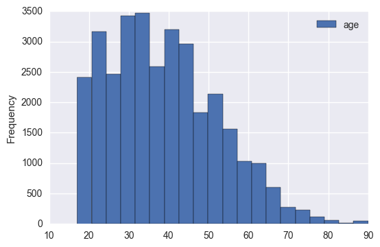

```python
#Histogram
#visualizing the age distribution of the census data
mydata.age.plot.hist(bins=20)
plt.legend()
```

The age distribution between 20years and 55years were quite frequent. The lowest age was about 20years old and the highest is about 90 years old. Finally, the histogram is skewed to the right or positively skewed.

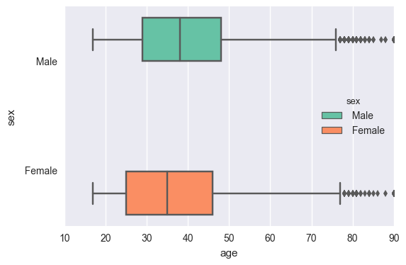

```python
#Boxplot
#Visualizing age vs sex of the census data
sns.boxplot(x ='age',y ='sex',hue ='sex', orient ="h",data= mydata,palette ='Set2',saturation =1, notch =False)
```

The male age distribution in the first quartile is mostly distributed around 29 years old, second quartile is around 38 years old which is the median, third quartile is mostly 49 years old. The female age distribution in the first quartile is mostly distributed around 25 years old, second quartile is around 35 years old which is the median, third quartile around 47 years old. Most of the outliers is indicated by the diamond symbol and located at the right whiskers between the ages of 78 years old and 90 years old In both the male and female age distribution most of the observation is skewed to the low end of the scale, the distribution is skewed to the right.

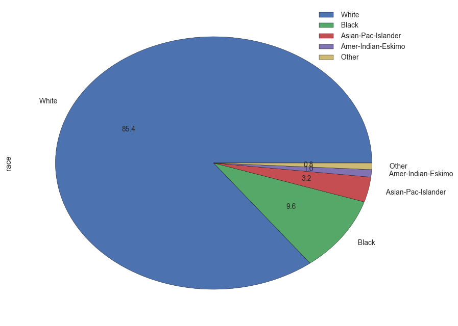

```python
# Pie Chart
#visualizing race of the census data
mydata.race.value_counts().plot(kind='pie', autopct='%.1f',fontsize=10, figsize=(10, 8))
plt.legend()
```

85.4% of the census data is White, 9.6% is Black, Asian-Pac-Islander accounted for 3.2% of the population, American -Indian-Eskimo accounted for 1.0% of the population, while Other race accounted for just 0.8% of the total population. The White population is dominant here accounting for 85.4% of the total population. Followed by the Black population accounting for only 9.6% of the total population.

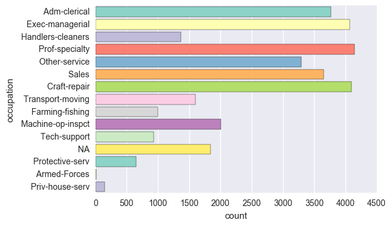

```python
#Barplot
#Visualizing the occupation distribution of the census data
sns.countplot(y='occupation', data=mydata,saturation=1, palette="Set3")
```

The highest recorded occupation accounted for Over 4000 individual that belong to the Prof-specialty, Exec-managerial,and Craft-repair occupation respectively. The lowest recorded occupation is the Armed-Forces, and Priv-house-serv accounting for less than 100 and 200 respectively. About 1800 individuals did not disclose their occupation. We can assume they are unemployed or self-employed.

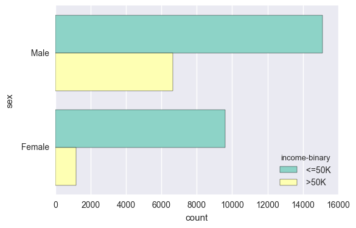

```python
#Barplot
#visualizing sex vs income-binary of the census data
sns.countplot(y="sex", hue="income-binary", data= mydata,saturation=1, palette="Set3")
```

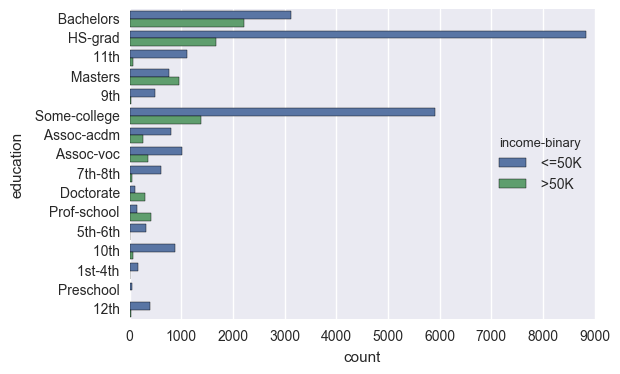

```python
#Barplot
#visualizing education vs income-binary of the census data
sns.countplot(y="education", hue="income-binary", data= mydata)
```

Most of the population distribution are high school graduate, and Some-college graduate and earned below 50k respectively.Some Individuals with Bachelors, High-school, Some-college, and masters earned above 50k.

### 6 - Feature Relationships (15%)

### 7 - Feature : Class Relationship Explanation (10%)

### 8 - Additional Features Discussion (5%)

### 9 - Exceptional Work (10%)